# Adverse Event Data Visualization for ClinicalTrials.Gov Data

# Downloading Data

```r
# URL of Trial: https://www.clinicaltrials.gov/study/NCT03515837

url_ctgov <- "https://www.clinicaltrials.gov/study/NCT03515837"
q <- ctrGetQueryUrl(url = url_ctgov)

dbc <- nodbi::src_sqlite(dbname = "my_db", collection = "my_coll")

ctrLoadQueryIntoDb(queryterm = q, con = dbc)

ae_fields <- c("resultsSection.adverseEventsModule.eventGroups.title",
               "resultsSection.adverseEventsModule.eventGroups.id",
               "resultsSection.adverseEventsModule.otherEvents.organSystem",
               "resultsSection.adverseEventsModule.otherEvents.term",
               "resultsSection.adverseEventsModule.otherEvents.stats",
               "resultsSection.adverseEventsModule.seriousEvents.organSystem",
               "resultsSection.adverseEventsModule.seriousEvents.term",
               "resultsSection.adverseEventsModule.seriousEvents.stats")

# In case you want other fields
# dbFindFields(namepart = "adverse", sample = FALSE, con = dbc)

result <- dbGetFieldsIntoDf(
  fields = ae_fields,
  con = dbc)

# making arm and arm description dataset (to append later)
arm <- trimws(unlist(strsplit(result$resultsSection.adverseEventsModule.eventGroups.id, "/")))
arm_desc <- trimws(unlist(strsplit(result$resultsSection.adverseEventsModule.eventGroups.title, "/")))
arm_df <- data.frame(arm, arm_desc)

# -- unnesting/unlisting the data -- #
ae_clean <- list()
for (type in c("other", "serious")){

  # subset to other or serious
  df_subset <- result %>%
      select(contains(type))

  # remove long names
  names(df_subset) <- sub(".*\\.", "", names(df_subset))

  # Seperate the variables that are listed as one long string
  organSystem <- df_subset$organSystem
  term <- df_subset$term

  # Unnest Stats
  df_unnest <- df_subset %>%
    unnest(stats) %>%
    rename(arm = groupId, organSystemName = organSystem)

  organSystem_clean <- rep(trimws(unlist(strsplit(organSystem, "/"))), each = length(unique(df_unnest$arm)))
  term_clean <- rep(trimws(unlist(strsplit(term, "/"))), each = length(unique(df_unnest$arm)))

  ae_clean[[type]] <- df_unnest %>%
    mutate(organSystemName = organSystem_clean,
           term = term_clean,
           event_type = type)
}

ae_ctgov_df <- bind_rows(ae_clean) %>%
  # adding arm description for labeling
  left_join(arm_df, by = "arm")
```

## Radar plot

### Prepping the Data

This is an example of what the data looks like that was downloaded from clinicaltrials.gov:

```r
ae_ctgov_df %>%
  kable()  %>%
  kable_styling(bootstrap_options = c("striped", "hover", "condensed")) %>%
    scroll_box(width = "950px", height = "410px")
```

| organSystemName | term | arm | numEvents | numAffected | numAtRisk | event_type | arm_desc |
| --- | --- | --- | --- | --- | --- | --- | --- |
| Blood and lymphatic system disorders | Anaemia | EG000 | 161 | 99 | 245 | other | Pembro + Pemetrexed + Chemo |
| Blood and lymphatic system disorders | Anaemia | EG001 | 177 | 110 | 246 | other | Placebo + Pemetrexed + Chemo |
| Blood and lymphatic system disorders | Anaemia | EG002 | 4 | 4 | 50 | other | Placebo + Pemetrexed + Chemo Switched Over to Pembro Monotherapy |
| Endocrine disorders | Hyperthyroidism | EG000 | 25 | 13 | 245 | other | Pembro + Pemetrexed + Chemo |
| Endocrine disorders | Hyperthyroidism | EG001 | 4 | 3 | 246 | other | Placebo + Pemetrexed + Chemo |
| Endocrine disorders | Hyperthyroidism | EG002 | 0 | 0 | 50 | other | Placebo + Pemetrexed + Chemo Switched Over to Pembro Monotherapy |
| Endocrine disorders | Hypothyroidism | EG000 | 18 | 14 | 245 | other | Pembro + Pemetrexed + Chemo |
| Endocrine disorders | Hypothyroidism | EG001 | 9 | 6 | 246 | other | Placebo + Pemetrexed + Chemo |
| Endocrine disorders | Hypothyroidism | EG002 | 3 | 3 | 50 | other | Placebo + Pemetrexed + Chemo Switched Over to Pembro Monotherapy |
| Gastrointestinal disorders | Abdominal pain | EG000 | 9 | 9 | 245 | other | Pembro + Pemetrexed + Chemo |
| Gastrointestinal disorders | Abdominal pain | EG001 | 15 | 15 | 246 | other | Placebo + Pemetrexed + Chemo |
| Gastrointestinal disorders | Abdominal pain | EG002 | 2 | 2 | 50 | other | Placebo + Pemetrexed + Chemo Switched Over to Pembro Monotherapy |
| Gastrointestinal disorders | Constipation | EG000 | 124 | 81 | 245 | other | Pembro + Pemetrexed + Chemo |
| Gastrointestinal disorders | Constipation | EG001 | 103 | 76 | 246 | other | Placebo + Pemetrexed + Chemo |
| Gastrointestinal disorders | Constipation | EG002 | 1 | 1 | 50 | other | Placebo + Pemetrexed + Chemo Switched Over to Pembro Monotherapy |
| Gastrointestinal disorders | Diarrhoea | EG000 | 27 | 24 | 245 | other | Pembro + Pemetrexed + Chemo |
| Gastrointestinal disorders | Diarrhoea | EG001 | 23 | 18 | 246 | other | Placebo + Pemetrexed + Chemo |
| Gastrointestinal disorders | Diarrhoea | EG002 | 0 | 0 | 50 | other | Placebo + Pemetrexed + Chemo Switched Over to Pembro Monotherapy |
| Gastrointestinal disorders | Nausea | EG000 | 242 | 96 | 245 | other | Pembro + Pemetrexed + Chemo |
| Gastrointestinal disorders | Nausea | EG001 | 237 | 107 | 246 | other | Placebo + Pemetrexed + Chemo |
| Gastrointestinal disorders | Nausea | EG002 | 4 | 4 | 50 | other | Placebo + Pemetrexed + Chemo Switched Over to Pembro Monotherapy |
| Gastrointestinal disorders | Vomiting | EG000 | 61 | 48 | 245 | other | Pembro + Pemetrexed + Chemo |
| Gastrointestinal disorders | Vomiting | EG001 | 55 | 44 | 246 | other | Placebo + Pemetrexed + Chemo |
| Gastrointestinal disorders | Vomiting | EG002 | 5 | 5 | 50 | other | Placebo + Pemetrexed + Chemo Switched Over to Pembro Monotherapy |
| General disorders | Asthenia | EG000 | 41 | 29 | 245 | other | Pembro + Pemetrexed + Chemo |
| General disorders | Asthenia | EG001 | 31 | 28 | 246 | other | Placebo + Pemetrexed + Chemo |
| General disorders | Asthenia | EG002 | 0 | 0 | 50 | other | Placebo + Pemetrexed + Chemo Switched Over to Pembro Monotherapy |
| General disorders | Chest pain | EG000 | 17 | 17 | 245 | other | Pembro + Pemetrexed + Chemo |
| General disorders | Chest pain | EG001 | 10 | 9 | 246 | other | Placebo + Pemetrexed + Chemo |
| General disorders | Chest pain | EG002 | 3 | 3 | 50 | other | Placebo + Pemetrexed + Chemo Switched Over to Pembro Monotherapy |

[output cut: 471 more lines]

Since we don’t have patient level data to find out how many individuals were in each category, we will use the highest count per category’s term as a way to display “at least this many people had an AE in this category”:

```r
max_term_per_cat <- ae_ctgov_df %>%
  group_by(event_type, organSystemName, arm) %>%
  arrange(desc(numAffected), .by_group=TRUE) %>%
  filter(row_number()==1) %>%
  ungroup()
```

Now we are ready to begin building the dataset. Let’s start by renaming the categories to something shorter, but still informative:

```r
# Using manual renaming from excel sheet
renaming_dat <- read_xlsx("Standardized Renaming//MEDRA_Word_Conversions.xlsx")

filtered_data <- max_term_per_cat %>%
  left_join(renaming_dat, by = "organSystemName") %>%
  select(-organSystemName) %>%
  rename(organSystemName = 'New Name') %>%
  relocate(organSystemName, .after=term) %>%
  arrange(desc(numAffected)) %>%

  # make pct var
  mutate(pct_affected = numAffected/numAtRisk) %>%

  # this arm is experimental so removing for visualization purposes
  filter(!arm == "EG002")
```

Then we want to write a loop that takes in the data per event type, takes the ten most prelevant categories, makes each category a column with its own count, and creates a row per arm.

```r
event_data <- list()
spider_plot_dat_list <- list()

for (event in sort(unique(filtered_data$event_type))) {

# Filtering grade and events
filtered_event_dat <- filtered_data %>%
  filter(event_type == event) %>%
  arrange(desc(numAffected))

# Taking the 10 most prevalent overall categories
categories <- filtered_event_dat %>%
  group_by(organSystemName) %>%
  mutate(total = sum(numAffected))  %>%
  arrange(desc(total))  %>%
  filter(row_number()==1)  %>%
  ungroup() %>%
  filter(row_number()==1:10) %>%
  pull(organSystemName)

filtered_event_dat <- filtered_event_dat %>%
  filter(organSystemName %in% categories)


# Pivoting to Wider for easiest formatting
event_data[[event]] <- filtered_event_dat %>%
  select(organSystemName, arm_desc, pct_affected) %>%
  pivot_wider(id_cols = organSystemName,
              names_from = arm_desc,
              # names_prefix = "Grade ",
              values_from = pct_affected,
              values_fill = 0) %>%
  complete(organSystemName =categories) %>%
  arrange(desc(`Placebo + Pemetrexed + Chemo`), desc(`Pembro + Pemetrexed + Chemo`)) %>%
  mutate(across(everything(), ~ replace_na(., 0)))

# Making the spider plot data
spider_plot_dat <- event_data[[event]]   %>%
  rename(Category = organSystemName)

spider_dat <- as.data.frame(t(spider_plot_dat))
names(spider_dat) <- lapply(spider_dat[1, ], as.character)
spider_dat <- spider_dat[-1,] %>%
  add_column(Name = rownames(spider_dat[-1,]), .before=1) %>%
   mutate(across(-Name, ~ as.numeric(.)))
rownames(spider_dat) <- NULL
# colnames(spider_dat) <- sapply(colnames(spider_dat), function(x) strsplit(x, " ")[[1]][1])

spider_plot_dat_list[[paste(event)]] <- spider_dat %>%
  mutate(Name = factor(Name,
                           levels = c("Placebo + Pemetrexed + Chemo",
                                      "Pembro + Pemetrexed + Chemo",
                                      "Pembro Monotherapy following PD on Placebo + Pemetrexed + Chemo")))

}
```

Here’s what the loop produces for “Other Events” for example:

```r
spider_plot_dat_list$`other` %>%
 kable()  %>%
 kable_styling(bootstrap_options = c("striped", "hover", "condensed")) %>%
    scroll_box(width = "950px", height = "150px")
```

| Name | Investigations | Blood/Lymph | Gastro | Nutrition | General | Respiratory | Nervous | Tissue | Infections | Psychiatric |
| --- | --- | --- | --- | --- | --- | --- | --- | --- | --- | --- |
| Placebo + Pemetrexed + Chemo | 0.4593496 | 0.4471545 | 0.4349594 | 0.2479675 | 0.199187 | 0.1300813 | 0.1260163 | 0.1016260 | 0.0731707 | 0.0691057 |
| Pembro + Pemetrexed + Chemo | 0.3673469 | 0.4040816 | 0.3918367 | 0.2612245 | 0.244898 | 0.1673469 | 0.1183674 | 0.1020408 | 0.0734694 | 0.0938776 |

Now, we are ready to create the plots!

### Creating Plot

For creating a plot where each grade is an entirely separate plot, we would loop through each grade as so:

```r
color <- c("#619CFF", "#00BA38")
title <- names(spider_plot_dat_list)
spider_plots <- list()

# Create the radar chart
for(i in names(spider_plot_dat_list)){

color_fix <- color
if (nrow(spider_plot_dat_list[[i]]) < length(color)) {
  color_fix <- color[(length(color) - nrow(spider_plot_dat_list[[i]]) + 1):length(color)]}

spider_plots[[i]] <- ggradar(spider_plot_dat_list[[i]],
        background.circle.colour = "white",
        legend.position = "bottom",
        font.radar = "serif",
        grid.min = 0,
        grid.mid = 0.5,
        grid.max = 1,
        axis.label.size = 3.5,
        grid.label.size = 4,
        legend.text.size = 10,
        grid.line.width = 0.5,
        group.colours = color_fix,
        group.point.size = 2.3,
        group.line.width = 1.2,
        # axis.label.offset = 1.2,
        gridline.label.offset = -0.005,
        centre.y = -0.2)  +
        # ggtitle(paste(i, "AEs"))  +
        theme(plot.title = element_text(size = 12,
                                        hjust = 0.5,
                                        face = "bold")) +
  theme(plot.margin = unit(c(0.1, 0.1, 0.1, 0.1), "lines")) +
guides(color = guide_legend(nrow = 3))
}
```

Here is the “other” plot for example:

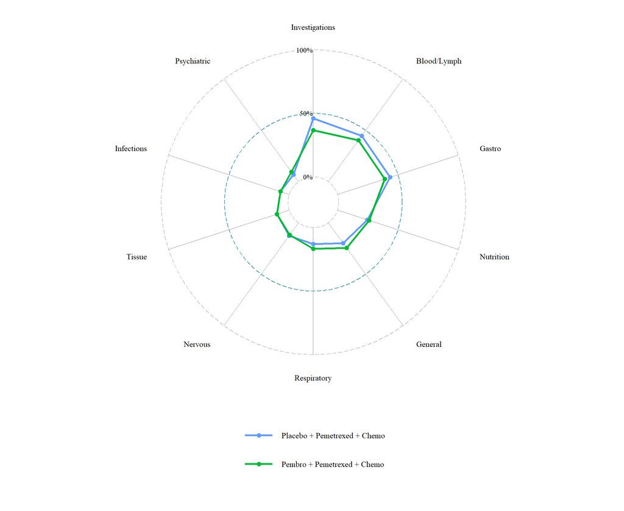

```r
spider_plots$other
```

Using ggarrange to put them all together

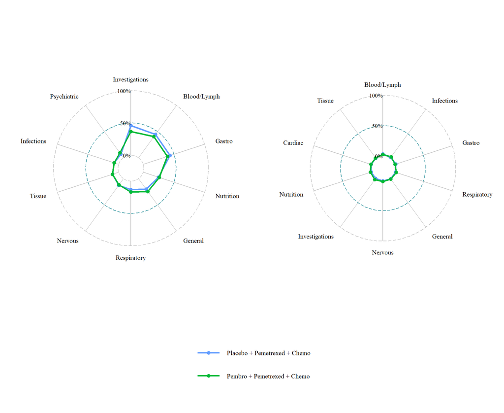

```r
radar_together <- ggarrange(plotlist = spider_plots, widths = c(1.7, 1.6), common.legend = TRUE,
          legend = "bottom")

radar_together
```

## Love Plots

If the number of patients for each arm are not comparable (as in one has a much higher count than another), then a love plot is a good option for displaying the data

The data does not really need to be altered too much, we just want to add a few variables that calculate percent of patients affect by each adverse event out of their arm

```r
love_plot_dat <- ae_ctgov_df   %>%
  filter(!arm == "EG002") %>%
  group_by(term, event_type) %>%
  # creating a percent variable to calculate num effect by term/event type (ignoring arm)
  mutate(total_pct_events = (sum(numAffected)/sum(numAtRisk))) %>%
  arrange(total_pct_events) %>%
  ungroup() %>%
  mutate(pct_affeced_by_arm = numAffected/numAtRisk)
```

### Creating Plot

We are going to make one plot for “other events” and one for “serious”

```r
# for other events
other_chart <- love_plot_dat %>%
  filter(event_type == "other") %>%
  mutate(term = forcats::fct_inorder(term)) %>%
  # picking events that happened over 5% of the time
ggplot(data = .,
       aes(x = pct_affeced_by_arm*100,
           y = term,
           group = arm_desc,
           color = arm_desc)) +
geom_point(size = 2) +
xlab("Percent of Patients Affected") +
geom_line(orientation = "y", linewidth = 0.9)  +
  theme_bw() +
   ggtitle("Other AEs") +
  scale_color_manual(values=c("#619CFF", "#00BA38")) +
  guides(colour=guide_legend(title="Treatment Arm"))

serious_chart <- love_plot_dat %>%
  filter(event_type == "serious") %>%
  mutate(term = forcats::fct_inorder(term)) %>%
  # picking events that happened over 5% of the time
  filter(total_pct_events > 0.0025) %>%
ggplot(data = .,
       aes(x = pct_affeced_by_arm,
           y = term,
           group = arm,
           color = arm,
           fill = arm)) +
geom_point(size = 2)  +
xlab("Percent of Patients Affected") +
 scale_color_manual(values=c("#619CFF", "#00BA38")) +
  geom_line(orientation = "y", linewidth = 0.9)  +
  theme_bw() +
  ggtitle("Serious AES")
```

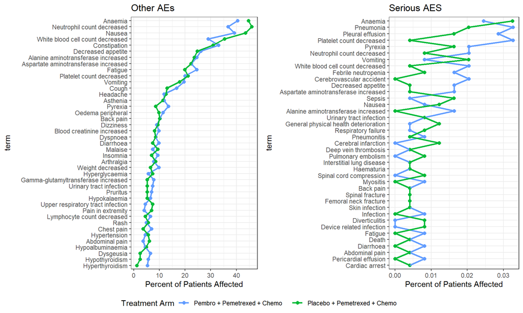

```r
ggarrange(other_chart, serious_chart,
          legend = "bottom", common.legend=TRUE,
          ncol = 2)
```

# Arranging together

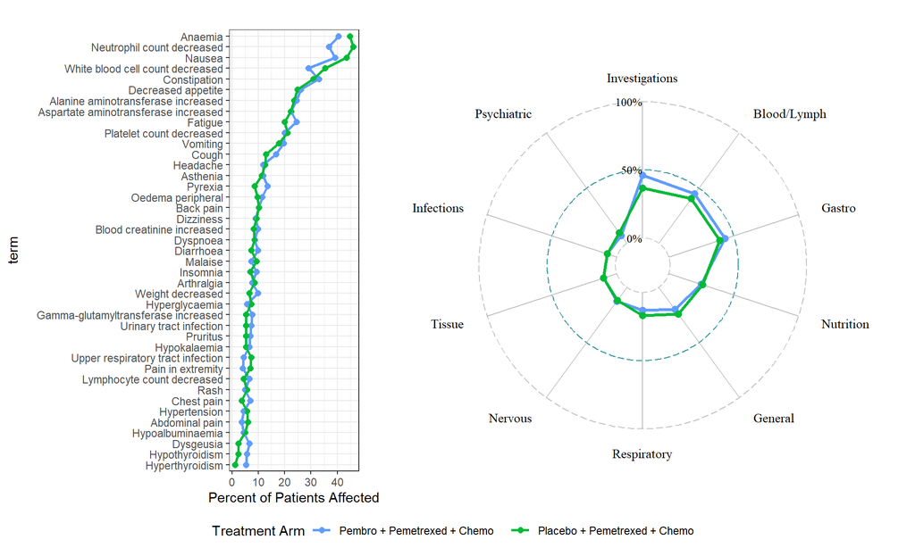

```r
final_plot <- ggarrange(other_chart + ggtitle(""),
                        spider_plots$other + ggtitle(""),
                        common.legend = TRUE, legend = "bottom",
          widths = c(1, 1.5))

final_plot
```